# Life History Strategies in Lizards: Insights into the Slow-Fast Continuum

# Set Up

## Initilisation

### Load Libraries

```r
library(tidyverse)
library(corrplot) # For correlation plots
library(FactoMineR) # For PCA
library(factoextra) # For PCA plots
library(vegan) # For CCA
library(ggplot2)
library(rsample) # For sampling of data (split, analysis,..)
library(rpart)
library(rpart.plot)
library(randomForest)
library(tibble)
library(tidyr)
library(gridExtra)
library(factoextra)
library(caret)
```

### Knitting Configuration

```r
# Set to render chunks during the knitting process
knitr::opts_chunk$set(echo = TRUE)
```

### Set Up the Environment

```r
# Clear Environment
rm(list = ls())

# Set Working Directory
setwd("/Users/eamon/Desktop/MathToolsProject/R_Project/MathematicalTools/")

# Load Data
data <- read.csv("lizard.csv")
```

### View the Data

```r
str(data)
```

```
'data.frame':   740 obs. of  24 variables:
 $ Species                        : chr  "Agama Agama" "Agama Agama" "Agama hispida" "Caimanops amphiboluroides" ...
 $ Genus                          : chr  "Agama" "Agama" "Agama" "Caimanops" ...
 $ Family                         : chr  "Agamidae" "Agamidae" "Agamidae" "Agamidae" ...
 $ Population                     : chr  "Suacocco, Liberia 1952-1953" "Ibadan, NIgeria" "Kalahari Desert, Africa, 1969-1970" "Australia" ...
 $ Longitude                      : num  -9.05 3.92 21.25 119.1 119.62 ...
 $ Latitude                       : num  7.08 7.4 -27.03 -28.5 -27.08 ...
 $ Average.Female.adult.weight..g.: num  NA NA 31.9 NA 10 ...
 $ SD.Female.adult.weight..g.     : chr  NA NA "6.16" NA ...
 $ Sample.Size.Female.adult.weight: int  NA NA 28 NA 17 75 NA 41 741 120 ...
 $ Mean.F.SVL.adults..mm.         : num  85 97 94.8 94 62.9 ...
 $ SD.F.SVL.adults..mm.           : num  NA NA 6.91 7.07 4.43 ...
 $ Sample.size.Mean.F.SVL.adults  : int  63 NA 51 2 18 75 NA 41 756 120 ...
 $ F.SVL.at.maturity..mm.         : num  75 NA 76 89 57 44 48 49 47 51 ...
 $ Offspring.SVL..mm.             : num  32 NA 29 38 22 23 24 25 22 26 ...
 $ Mean.Clutch.Size               : num  7.5 5.5 13.4 12 5.36 ...
 $ Sample.size.Clutch.Size.       : int  NA NA 45 2 14 28 NA 13 40 39 ...
 $ Mode.of.reproduction           : chr  "Oviparous" "Oviparous" "Oviparous" "Oviparous" ...
 $ Clutches.per.year              : num  2 NA NA NA NA NA 2 NA NA NA ...
 $ Clutch.Frequency               : num  2 2 1 1 1 1 2 1 2 2 ...
 $ RCM                            : num  NA NA 0.305 NA 0.166 ...
 $ Foraging.Mode                  : chr  "Sit and wait" "Sit and wait" "Sit and wait" "Sit and wait" ...
 $ Distribution                   : chr  "Tropical" "Tropical" "Temperate" "Temperate" ...
 $ Prefered.Habitat.Type          : chr  "Saxicolous" "Saxicolous" "Semi-arboreal" "Semi-arboreal" ...
 $ Source                         : chr  "(Harris 1964)" "(Daniel 1960)" "(Pianka 1986)" "(Pianka 2013d)" ...
```

## Cleaning

### Change Variable Types

```r
# This variables was input as a character, but it should be numeric
data$SD.Female.adult.weight..g. <- as.numeric(data$SD.Female.adult.weight..g.)
```

### Set Blanks in Categorical Variables as NA

```r
# Convert the blank values of categorical variables to NA
data<-data %>%
  mutate(across(where(is.character), ~ na_if(.x, ""))) %>%
  mutate(across(where(is.character), as.factor))
```

### Check for and Remove Duplicates

```r
# Save duplicates as an object
duplicates <- data[duplicated(data), ]

# Remove duplicates
data <- data[!duplicated(data), ]
```

### Visualise the Proportion of Each Variable Which is NA

By doing this we found that most of the numeric variables had a high proportion of NA’s, with some such as RCM having over 50%. Therefore exclusion of all rows containing NA’s was likely to drastically reduce the size dataset and cause data loss. The number of rows in the original dataset was 734 and the number after exclusion of all NAs was 146. Therefore the NA’s were removed separately for each analysis using only the variables required for that analysis, which helped to reduce data loss.

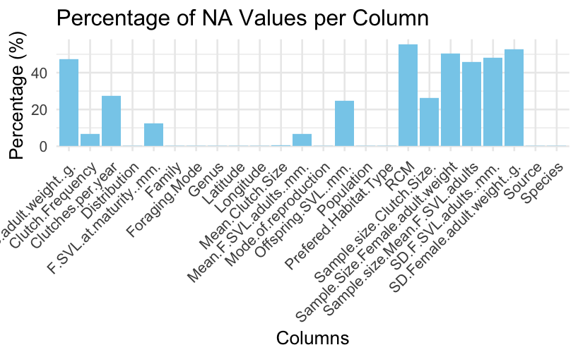

```r
# Calculate percentage of NA values for each column
na_percentage <- colSums(is.na(data)) / nrow(data) * 100

# Convert NA percentages to a data frame
na_df <- data.frame(
  Column = names(na_percentage),
  NA_Percentage = na_percentage
)

# Create bar plot
ggplot(na_df, aes(x = Column, y = NA_Percentage)) +
  geom_bar(stat = "identity", fill = "skyblue") +
  labs(
    title = "Percentage of NA Values per Column",
    x = "Columns",
    y = "Percentage (%)"
  ) +
  theme_minimal() +
  theme(
    axis.text.x = element_text(angle = 45, hjust = 1) # Rotate x-axis labels
  )
```

```r
# Print the number of rows in the full dataset
print(paste("Number of rows in full dataset =", nrow(data)))
```

```
[1] "Number of rows in full dataset = 734"
```

```r
# Print the number of rows after NA removal
print(paste("Number of rows after NA removal on entire dataset =", nrow(na.omit(data))))
```

```
[1] "Number of rows after NA removal on entire dataset = 146"
```

# PCA

### Choose the Variables to be Used in the PCA

This saves the variables to be used in the PCA as an object. The variables used are easily altered by commenting them in or out. Only numerical variables are considered as candidates as PCA can only use numerical variables. Where two variables describe the same trait, one of them was removed. This was done in order to avoid bias in the PCA by over emphasising particular traits.

“F.SVL.at.maturity..mm” describes the same trait as “Mean.F.SVL.adults..mm.”. A correlation of these two variables revealed a 97% correlation. Therefore, “F.SVL.at.maturity..mm.” was randomly chosen to be removed.

Sample sizes and standard deviations were removed from the analysis as they were not thought to be relevant.

```r
variables_to_use_PCA <- c(
  ### Location
  #"Longitude",
  #"Latitude",

  ### Means and Numerical
  "Average.Female.adult.weight..g.",
  "Mean.F.SVL.adults..mm.",
  #"F.SVL.at.maturity..mm.",
  "Offspring.SVL..mm.",
  "Mean.Clutch.Size",
  "Clutches.per.year",
  #"Clutch.Frequency",
  "RCM"

  ### Standard Deviations and Sample Sizes
  #"SD.Female.adult.weight..g.",
  #"SD.F.SVL.adults..mm.",
  #"Sample.Size.Female.adult.weight",
  #"Sample.size.Mean.F.SVL.adults",
)
```

### Investigation of the Similar Variables

```r
# Are clutch frequency and clutches per year the same?
cor(data$Clutch.Frequency, data$Clutches.per.year, use = "complete.obs") # Correlation of the two variables
```

```
[1] 0.7993801
```

```r
unique(data$Clutch.Frequency) # Unique values of clutch frequency
```

```
[1] 2.00 1.00   NA 0.50 0.75
```

```r
unique(data$Clutches.per.year) # Unique values of clutches per year
```

```
 [1] 2.00   NA 3.00 1.00 4.00 6.00 0.50 0.75 2.50 1.50 1.30 3.50 5.00 5.50
```

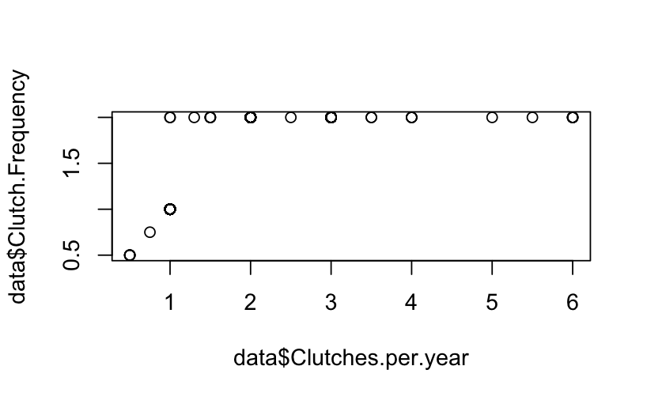

```r
plot(data$Clutch.Frequency~data$Clutches.per.year)
```

```r
# Are "F.SVL.at.maturity..mm." and "Mean.F.SVL.adults..mm." the same?
cor(data$F.SVL.at.maturity..mm., data$Mean.F.SVL.adults..mm., use="complete.obs")
```

```
[1] 0.9742323
```

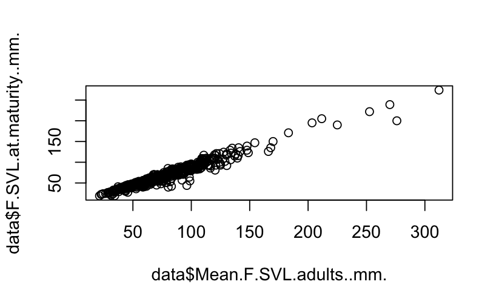

```r
plot(data$F.SVL.at.maturity..mm.~data$Mean.F.SVL.adults..mm.)
```

### Create New Dataset retaining only the PCA variables

Here a new subset of the data is created for the PCA. The PCA data was cleaned of all rows containing NA’s and standardised such that each variable has mean 0 and variance 1 (which allows for comparison of variables on different scales in the PCA). A second data set was created containing the rows retained after NA omition of the PCA data, but containing all the original variables. This is later used to color the PCA visualisations with categorical variables.

```r
# Create the new PCA dataset
data_PCA <- data %>%
  select(any_of(variables_to_use_PCA)) %>% # Filter for the variables to be used in the PCA
  na.omit() %>% # Omit NA's
  mutate_all(.funs = scale) # Scale the data for the PCA

# Create ancillary dataset with all original variables but filtered to keep only rows present in the PCA dataset
# This will be used for coloration of the PCA graphs with categorical variables
data_PCA_all_vars <- data %>%
  filter(row_number() %in% rownames(data_PCA))
```

### Visualise with a Correlation

This shows the correlation of each variable pairs in PCA data.

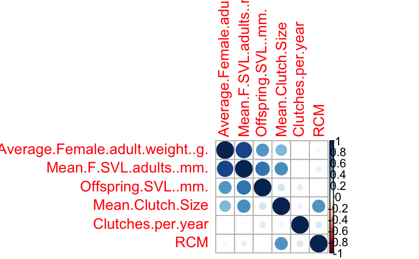

```r
### CorrPlot
data_PCA %>%
  cor(use="pairwise.complete.obs") %>% # Calculate the empirical correlation matrix
  corrplot() # Then graph this matrix
```

### Run the PCA

```r
# Run the PCA
result_pca <- PCA(data_PCA,
               scale.unit = TRUE, # Option to center and scale data (useless here)
               ncp = 18, # Number of components to keep (here, all)
               graph = FALSE)

# Results of the PCA
result_pca$eig
```

```
       eigenvalue percentage of variance cumulative percentage of variance
comp 1  2.6587109              44.311849                          44.31185
comp 2  1.3619758              22.699597                          67.01145
comp 3  1.0045260              16.742100                          83.75355
comp 4  0.5390329               8.983881                          92.73743
comp 5  0.3322868               5.538113                          98.27554
comp 6  0.1034676               1.724460                         100.00000
```

```r
result_pca$var
```

```
$coord
                                     Dim.1      Dim.2       Dim.3      Dim.4       Dim.5         Dim.6
Average.Female.adult.weight..g. 0.85963737 -0.2569125 -0.08119133 -0.2247602  0.33782916  0.1542136295
Mean.F.SVL.adults..mm.          0.94322791 -0.1831013 -0.03597327 -0.1070915 -0.01004919 -0.2528465494
Offspring.SVL..mm.              0.70026847 -0.3611057  0.26986262  0.5219441 -0.16737336  0.0772103875
Mean.Clutch.Size                0.67230627  0.5642295 -0.21604108 -0.2231893 -0.35306297  0.0922424835
Clutches.per.year               0.09330088  0.2936980  0.93164341 -0.1913058  0.02186568 -0.0009825451
RCM                             0.28103187  0.8528980 -0.09581677  0.3438170  0.25477804 -0.0358229942

$cor
                                     Dim.1      Dim.2       Dim.3      Dim.4       Dim.5         Dim.6
Average.Female.adult.weight..g. 0.85963737 -0.2569125 -0.08119133 -0.2247602  0.33782916  0.1542136295
Mean.F.SVL.adults..mm.          0.94322791 -0.1831013 -0.03597327 -0.1070915 -0.01004919 -0.2528465494
Offspring.SVL..mm.              0.70026847 -0.3611057  0.26986262  0.5219441 -0.16737336  0.0772103875
Mean.Clutch.Size                0.67230627  0.5642295 -0.21604108 -0.2231893 -0.35306297  0.0922424835
Clutches.per.year               0.09330088  0.2936980  0.93164341 -0.1913058  0.02186568 -0.0009825451
RCM                             0.28103187  0.8528980 -0.09581677  0.3438170  0.25477804 -0.0358229942

$cos2
                                      Dim.1      Dim.2       Dim.3      Dim.4        Dim.5        Dim.6
Average.Female.adult.weight..g. 0.738976402 0.06600404 0.006592032 0.05051714 0.1141285410 2.378184e-02
Mean.F.SVL.adults..mm.          0.889678897 0.03352608 0.001294076 0.01146858 0.0001009861 6.393138e-02
Offspring.SVL..mm.              0.490375929 0.13039736 0.072825833 0.27242560 0.0280138408 5.961444e-03
Mean.Clutch.Size                0.451995725 0.31835491 0.046673750 0.04981348 0.1246534573 8.508676e-03
Clutches.per.year               0.008705054 0.08625851 0.867959438 0.03659793 0.0004781078 9.653950e-07
RCM                             0.078978909 0.72743495 0.009180853 0.11821016 0.0649118488 1.283287e-03

$contrib
                                     Dim.1     Dim.2      Dim.3     Dim.4       Dim.5        Dim.6
Average.Female.adult.weight..g. 27.7945375  4.846198  0.6562331  9.371810 34.34639813 2.298482e+01
Mean.F.SVL.adults..mm.          33.4627917  2.461577  0.1288245  2.127622  0.03039126 6.178879e+01
Offspring.SVL..mm.              18.4441237  9.574131  7.2497710 50.539699  8.43062147 5.761653e+00
Mean.Clutch.Size                17.0005592 23.374490  4.6463457  9.241270 37.51381762 8.223518e+00
Clutches.per.year                0.3274164  6.333336 86.4048768  6.789554  0.14388407 9.330409e-04
RCM                              2.9705715 53.410268  0.9139488 21.930045 19.53488745 1.240279e+00
```

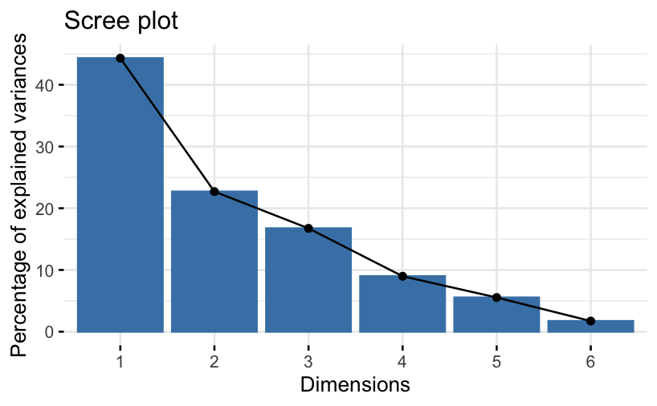

```r
# Plot the Scree Plot to Show Variance Explained by Each Dimension
fviz_eig(result_pca, choice = "variance")
```

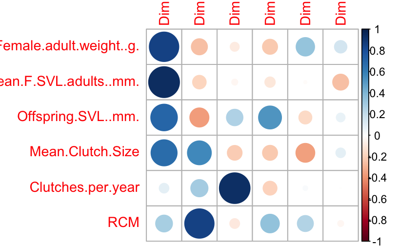

```r
# Plot the Correlation of Each Variable and the Dimension
corrplot(result_pca$var$cor)
```

### Plot the Individuals with the Variable Arrows and the Categorical Coloring

By altering the object Color_label we were able to check the effect of coloring with each of the four main categorical variables (Distribution, Habitat type, Foraging mode and Reproductive type). It was found that distribution produced the clearest clustering with the least noise. Therefore distribution was taken forward as a potential categorical variable which can account for much of the variation.

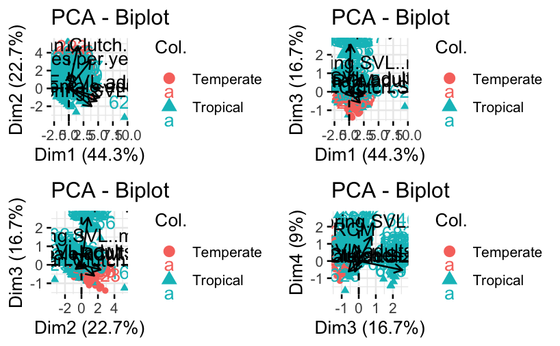

```r
Color_label <- "Distribution"

### Plot all four on one plot
# Generate the plots
p1 <- fviz_pca_biplot(result_pca, axes = c(1, 2), col.ind = data_PCA_all_vars[[Color_label]], col.var = "black")
p2 <- fviz_pca_biplot(result_pca, axes = c(1, 3), col.ind = data_PCA_all_vars[[Color_label]], col.var = "black")
p3 <- fviz_pca_biplot(result_pca, axes = c(2, 3), col.ind = data_PCA_all_vars[[Color_label]], col.var = "black")
p4 <- fviz_pca_biplot(result_pca, axes = c(3, 4), col.ind = data_PCA_all_vars[[Color_label]], col.var = "black")

# Arrange the plots in a grid
grid.arrange(p1, p2, p3, p4, nrow = 2, ncol = 2)
```

# K-Means Clustering

### Create Clusters for 2-5 Groups Out of Curiosity

```r
# Create Clusters For Four Groups
first_kmeans <- data_PCA %>%
  kmeans(centers = 4)

# Within Group Inertia
first_kmeans$tot.withinss
```

```
[1] 390.3572
```

```r
kmeans_5groups<- data_PCA %>%
  kmeans(centers = 5)

kmeans_4groups<- data_PCA %>%
  kmeans(centers = 4)

kmeans_3groups<- data_PCA %>%
  kmeans(centers=3)

kmeans_2groups <- data_PCA %>%
  kmeans(centers=2)

# Extract the Clustering Groups
clusters_5groups <- kmeans_5groups$cluster
clusters_4groups <- kmeans_4groups$cluster
clusters_3groups <- kmeans_3groups$cluster
clusters_2groups <- kmeans_2groups$cluster
```

### Plot a Comparison of the 2 Group K-Means Clustering vs The Coloration Applied by the “Distribution” Variable

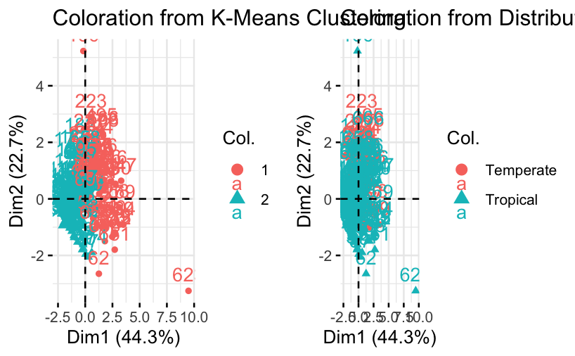

```r
# Define a color palette for consistency
custom_palette <- c("red", "blue", "green", "orange")

# Save each of the plots
p1A <- fviz_pca_ind(result_pca, axes = c(1, 2), col.ind = as.factor(clusters_2groups), col.var = "black", title = "Coloration from K-Means Clustering")
p1B <- fviz_pca_ind(result_pca, axes = c(1, 2), col.ind = data_PCA_all_vars[[Color_label]], col.var = "black", title = "Coloration from Distribution")
p2A <- fviz_pca_ind(result_pca, axes = c(1, 3), col.ind = as.factor(clusters_2groups), col.var = "black", title = "Coloration from K-Means Clustering")
p2B <- fviz_pca_ind(result_pca, axes = c(1, 3), col.ind = data_PCA_all_vars[[Color_label]], col.var = "black", title = "Coloration from Distribution")
p3A <- fviz_pca_ind(result_pca, axes = c(2, 3), col.ind = as.factor(clusters_2groups), col.var = "black", title = "Coloration from K-Means Clustering")
p3B <- fviz_pca_ind(result_pca, axes = c(2, 3), col.ind = data_PCA_all_vars[[Color_label]], col.var = "black", title = "Coloration from Distribution")
p4A <- fviz_pca_ind(result_pca, axes = c(3, 4), col.ind = as.factor(clusters_2groups), col.var = "black", title = "Coloration from K-Means Clustering")
p4B <- fviz_pca_ind(result_pca, axes = c(3, 4), col.ind = data_PCA_all_vars[[Color_label]], col.var = "black", title = "Coloration from Distribution")

# Plot each axis combination
grid.arrange(p1A, p1B, nrow = 1, ncol = 2)
```

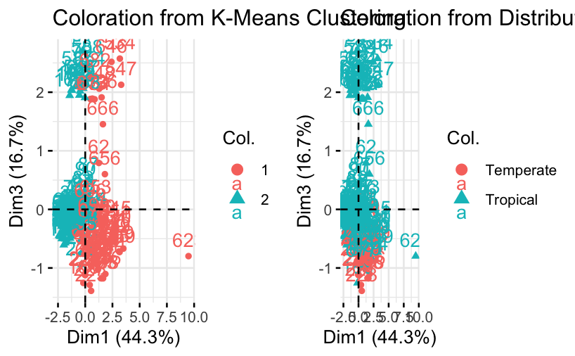

```r
grid.arrange(p2A, p2B, nrow = 1, ncol = 2)
```

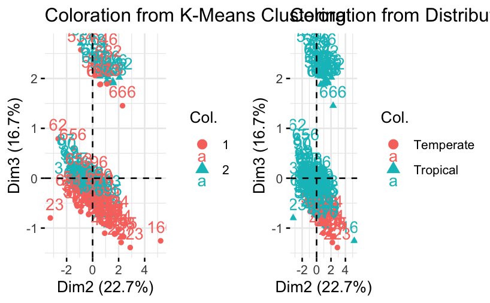

```r
grid.arrange(p3A, p3B, nrow = 1, ncol = 2)
```

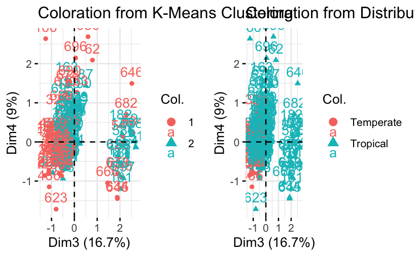

```r
grid.arrange(p4A, p4B, nrow = 1, ncol = 2)
```

[figure not shown]

```r
all_4_plots<-grid.arrange(p1A, p1B, p2A, p2B, p3A, p3B, p4A, p4B, nrow = 4, ncol=2)
```

```r
# Save a ggplot object
ggsave("all4dimensionsclustering.png", plot = all_4_plots, width = 11, height = 15.18, units = "in", dpi = 500)
```